# Network Models

Kalyan and Stepek

# Introduction

The aim of this assignment was to compute average shortest-path as a function of the parameter p of the WS model and plot the average shortest-path length as a function of the network size of the ER model. We chose to use `networkx library` for our analysis.

# Implementation

We followed all the instructions as per the pdf document. The first choice we had to take was to figure out the right value for the constant `z` (Average degree) and `p` in such a way that do not get isolated vertex.

### Erdos-Renyi Model

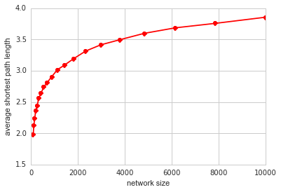

Erdos-Renyi Model

### Watts-Strogatz Model

We needed to compute clustering coefficient and average shortest-path as a function of parameter `p`. The constants we used were, `k = 4` (Nearest neighbors in ring topology), Size of graph `n = 500` (Since computaionally it did not take too much time). After obtaining these values over function of parameter `p` we normalized it to be within range `[0, 1]`. By Averaging the the cluster coefficient and shortest path over 10 different random seeds we obtained smoothed scatted plot below.The averaging was perfored using a function which for every p generated k values and returned their mean value.

[figure not shown]

Watts-Strogatz Model

# Results

We did not have any problem simulating the results. Using python comprehensions we were optimized our code and improved readibility. The plots obtained for Watts-Strogatz model gave us better results when averaged over multiple graphs with different random seeds.